# Movie Boxoffice Predictions 1

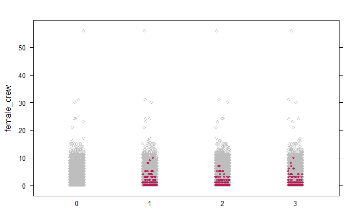

`r`r densityplot(imputations_cart, ~ male_crew | .imp)

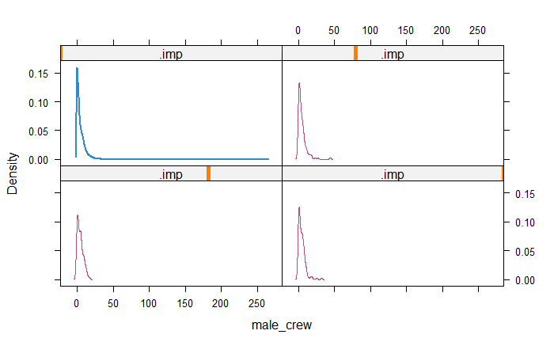

`r`r stripplot(imputations_cart, male_crew, col = c(, mdc(2)), pch = c(1, 20))

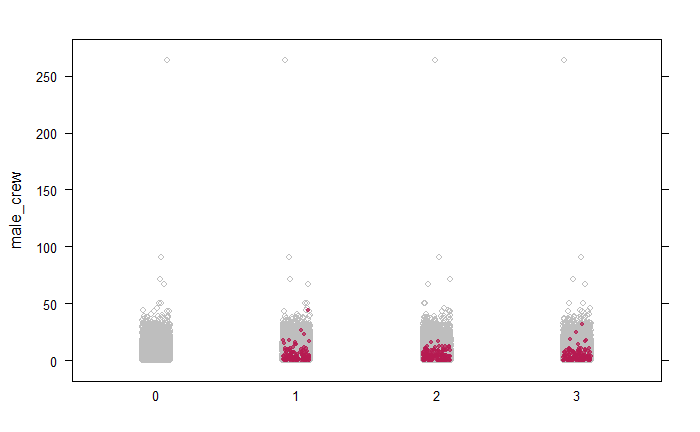

`r`r densityplot(imputations_cart, ~ unspecified_crew | .imp)

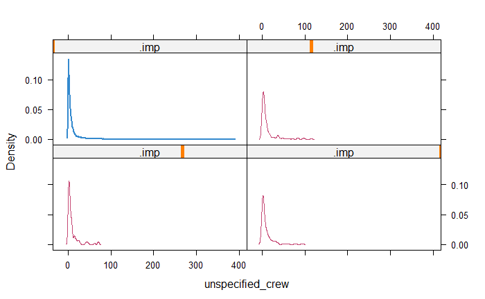

`r`r stripplot(imputations_cart, unspecified_crew, col = c(, mdc(2)), pch = c(1, 20))

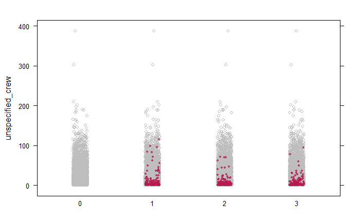

`r`r densityplot(imputations_cart, ~ comedy | .imp)

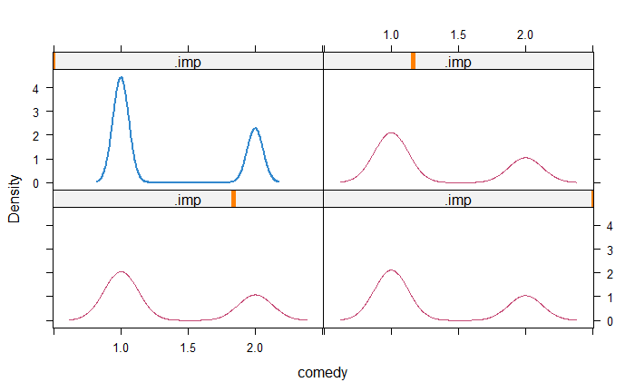

`r`r stripplot(imputations_cart, comedy, col = c(, mdc(2)), pch = c(1, 20))

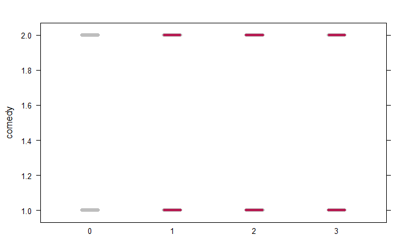

`r`r densityplot(imputations_cart, ~ horror | .imp)

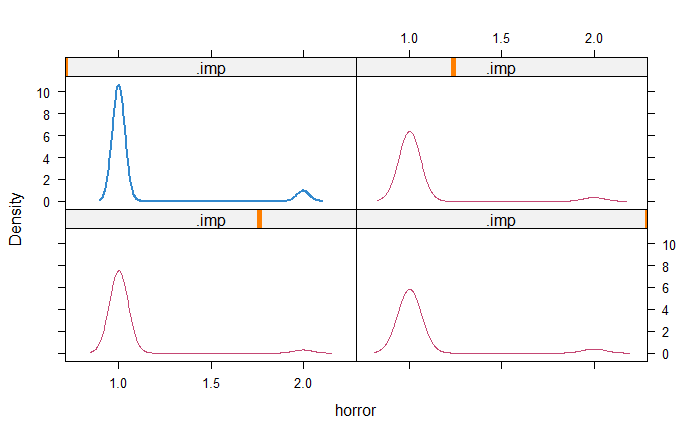

`r`r stripplot(imputations_cart, horror, col = c(, mdc(2)), pch = c(1, 20))

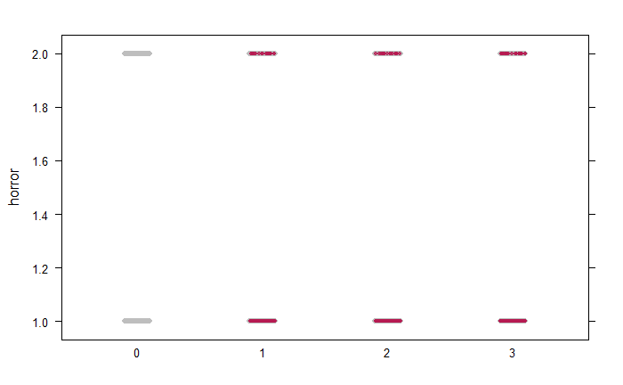

`r`r densityplot(imputations_cart, ~ action | .imp)

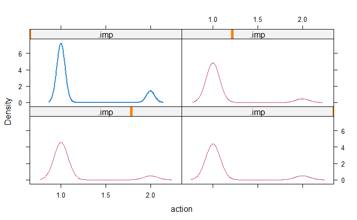

`r`r stripplot(imputations_cart, action, col = c(, mdc(2)), pch = c(1, 20))

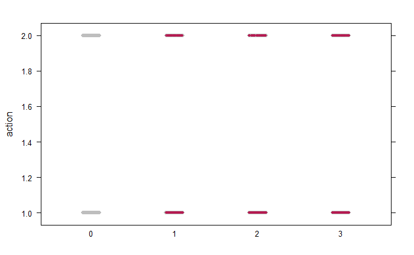

`r`r densityplot(imputations_cart, ~ drama | .imp)

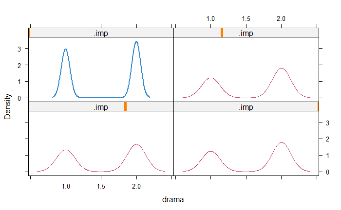

`r`r stripplot(imputations_cart, drama, col = c(, mdc(2)), pch = c(1, 20))

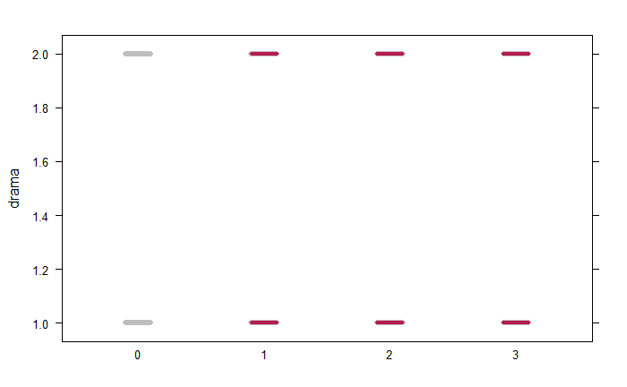

`r`r densityplot(imputations_cart, ~ documentary | .imp)

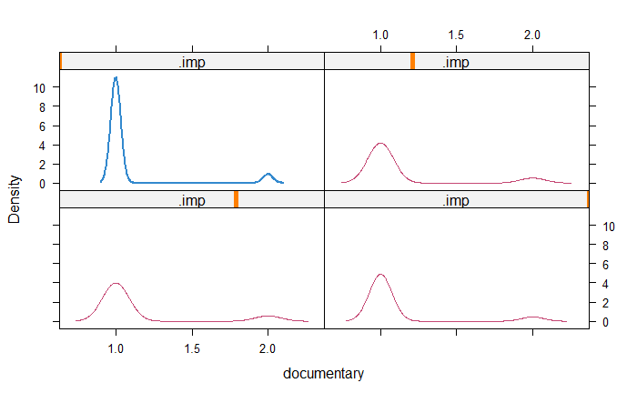

`r`r stripplot(imputations_cart, documentary, col = c(, mdc(2)), pch = c(1, 20))

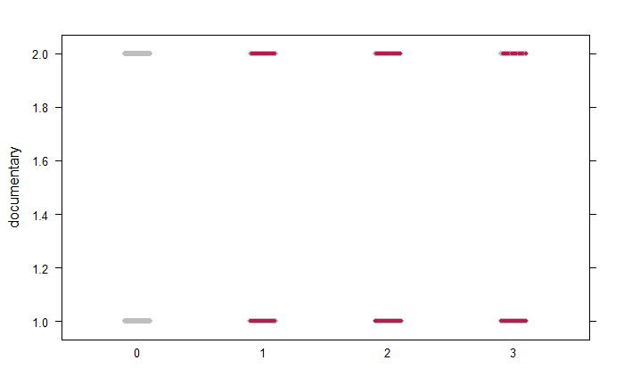

`r`r densityplot(imputations_cart, ~ science_fiction | .imp)

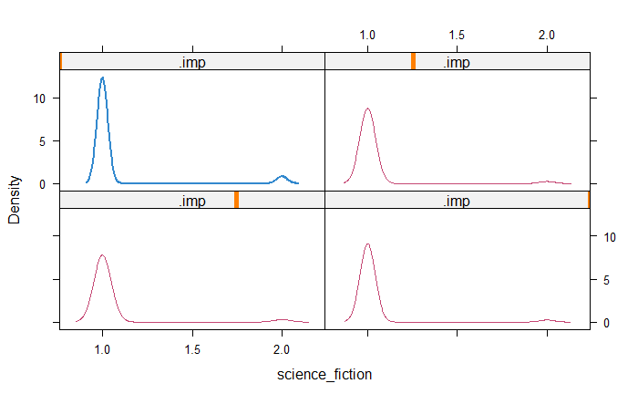

`r`r stripplot(imputations_cart, science_fiction, col = c(, mdc(2)), pch = c(1, 20))

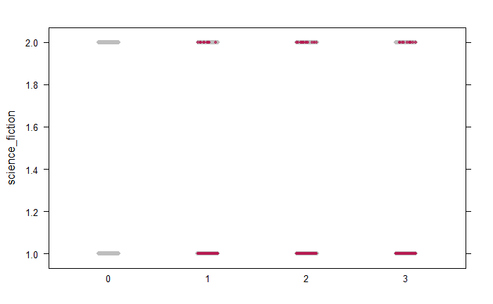

`r`r densityplot(imputations_cart, ~ crime | .imp)

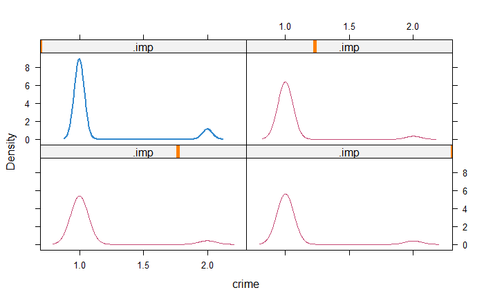

`r`r stripplot(imputations_cart, crime, col = c(, mdc(2)), pch = c(1, 20))

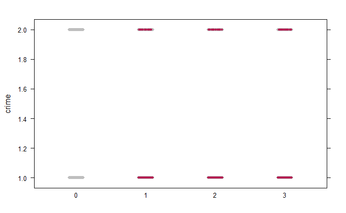

`r`r densityplot(imputations_cart, ~ fantasy | .imp)

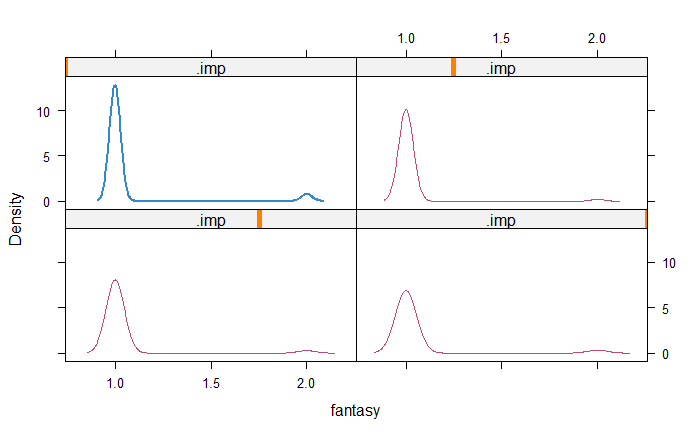

`r`r stripplot(imputations_cart, fantasy, col = c(, mdc(2)), pch = c(1, 20))

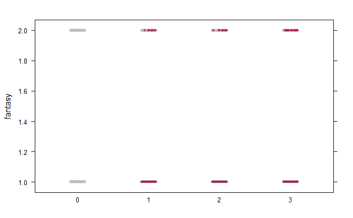

`r`r densityplot(imputations_cart, ~ thriller | .imp)

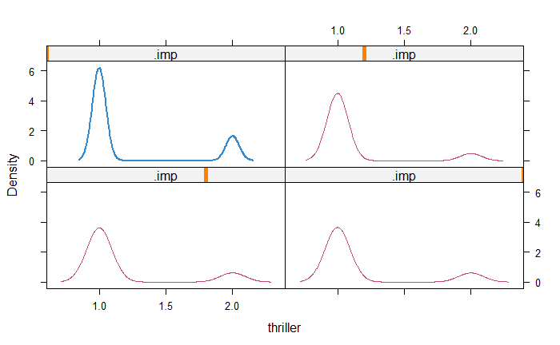

`r`r stripplot(imputations_cart, thriller, col = c(, mdc(2)), pch = c(1, 20))

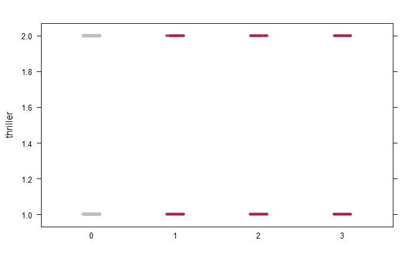

`r`r densityplot(imputations_cart, ~ animation | .imp)

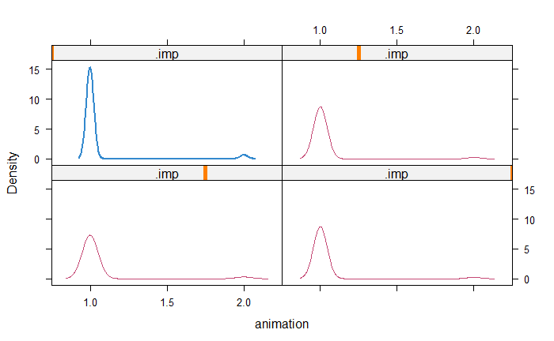

`r`r stripplot(imputations_cart, animation, col = c(, mdc(2)), pch = c(1, 20))

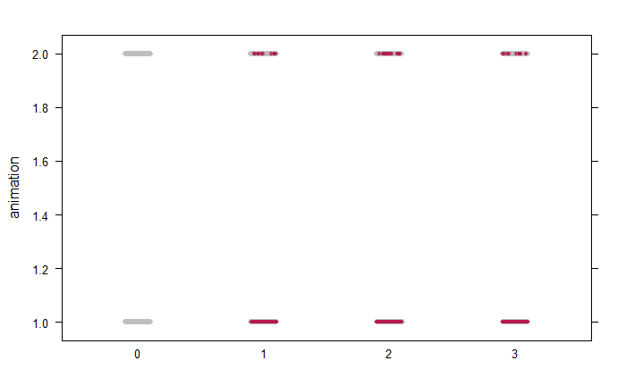

`r`r densityplot(imputations_cart, ~ adventure | .imp)

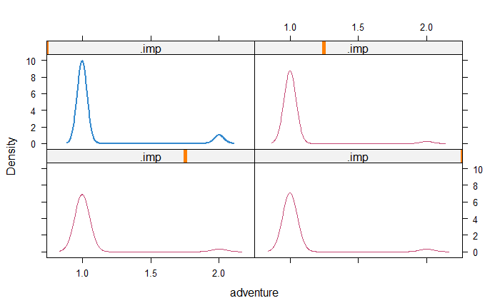

`r`r stripplot(imputations_cart, adventure, col = c(, mdc(2)), pch = c(1, 20))

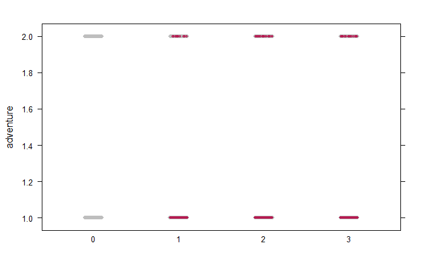

`r`r densityplot(imputations_cart, ~ mystery | .imp)

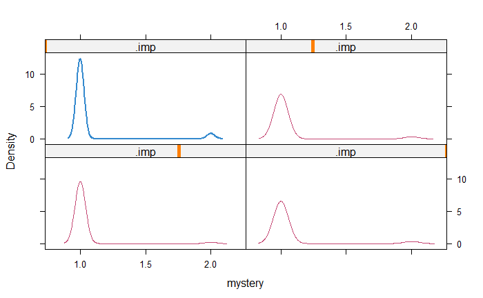

`r`r stripplot(imputations_cart, mystery, col = c(, mdc(2)), pch = c(1, 20))

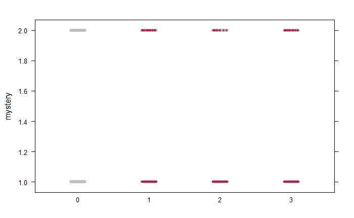

`r`r densityplot(imputations_cart, ~ war | .imp)

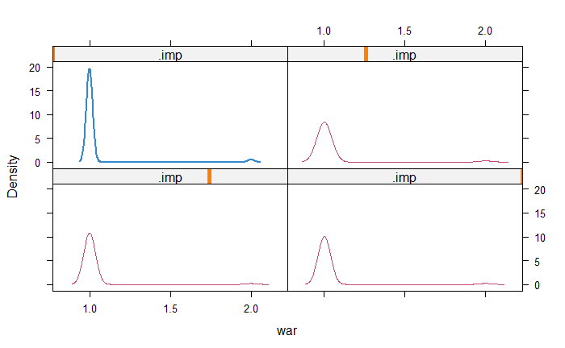

`r`r stripplot(imputations_cart, war, col = c(, mdc(2)), pch = c(1, 20))

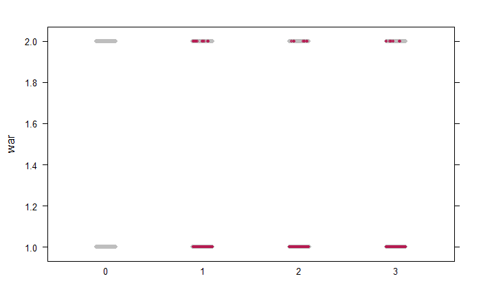

`r`r densityplot(imputations_cart, ~ romance | .imp)

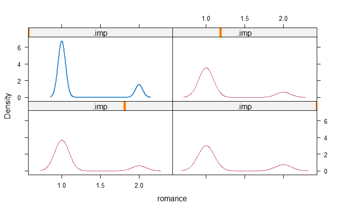

`r`r stripplot(imputations_cart, romance, col = c(, mdc(2)), pch = c(1, 20))

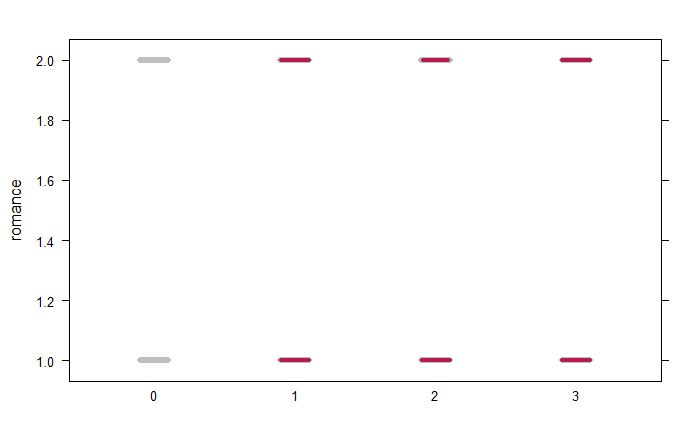

`r`r densityplot(imputations_cart, ~ music | .imp)

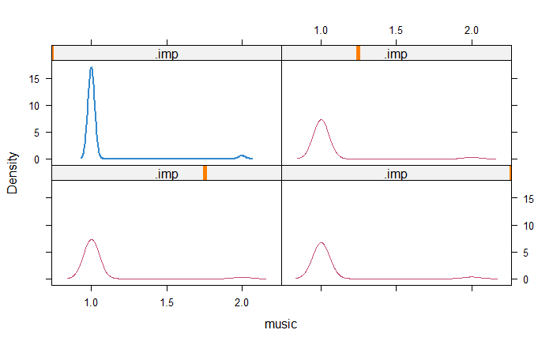

`r`r stripplot(imputations_cart, music, col = c(, mdc(2)), pch = c(1, 20))

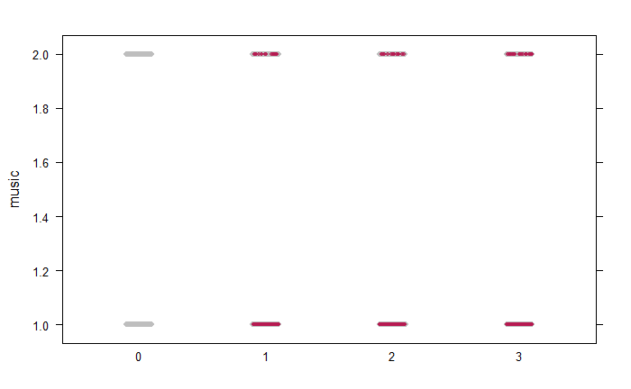

`r`r densityplot(imputations_cart, ~ family | .imp)

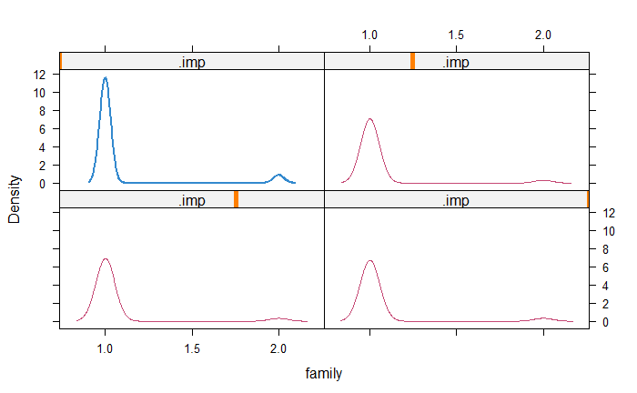

`r`r stripplot(imputations_cart, family, col = c(, mdc(2)), pch = c(1, 20))

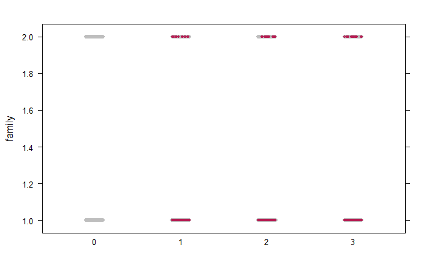

`r`r densityplot(imputations_cart, ~ western | .imp)

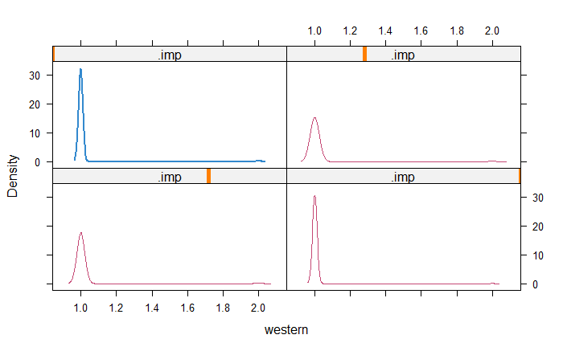

`r`r stripplot(imputations_cart, western, col = c(, mdc(2)), pch = c(1, 20))

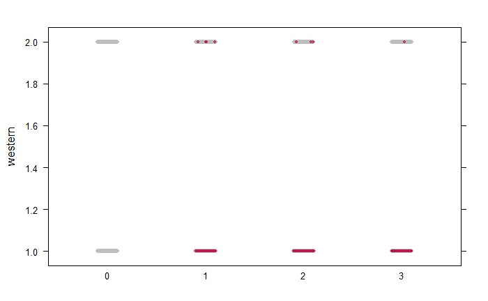

`r`r densityplot(imputations_cart, ~ history | .imp)

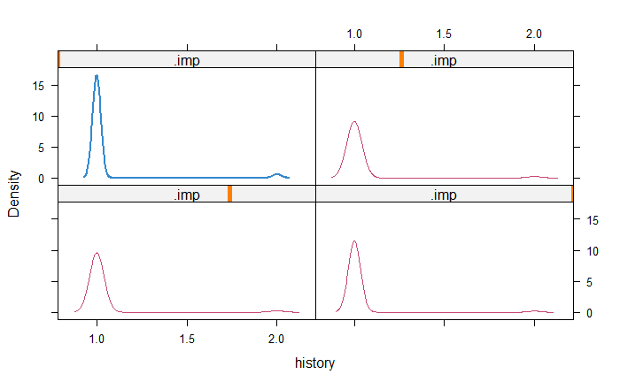

`r`r stripplot(imputations_cart, history, col = c(, mdc(2)), pch = c(1, 20))

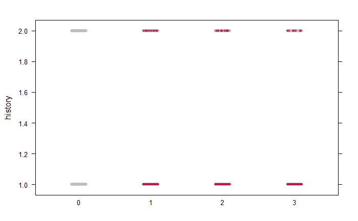

`r`r densityplot(imputations_cart, ~ tv_movie | .imp)

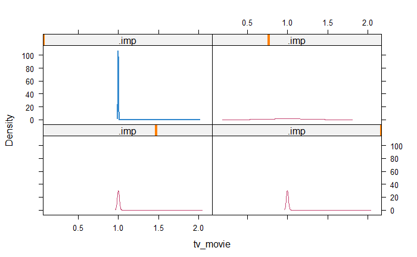

`r`r stripplot(imputations_cart, tv_movie, col = c(, mdc(2)), pch = c(1, 20))

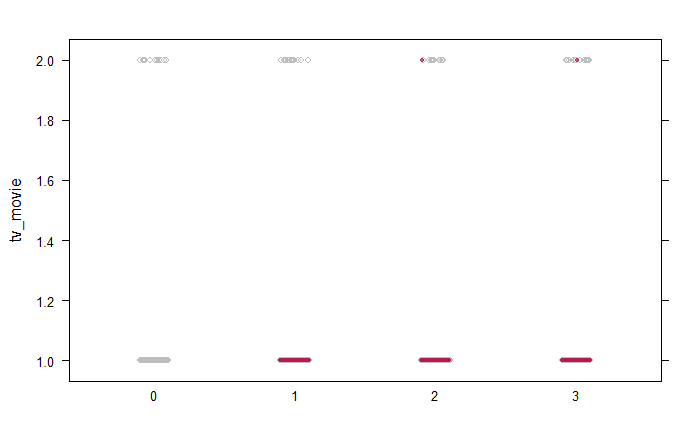

`r`r densityplot(imputations_cart, ~ foreign | .imp)

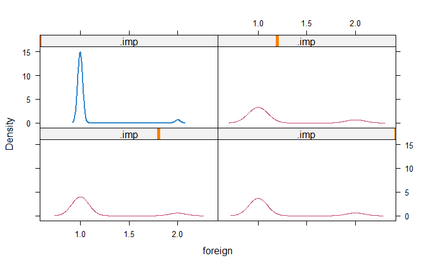

`r`r stripplot(imputations_cart, foreign, col = c(, mdc(2)), pch = c(1, 20))

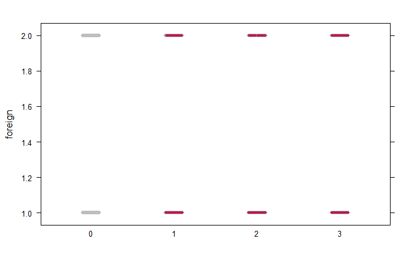

`r`r densityplot(imputations_cart, ~ paramount | .imp)

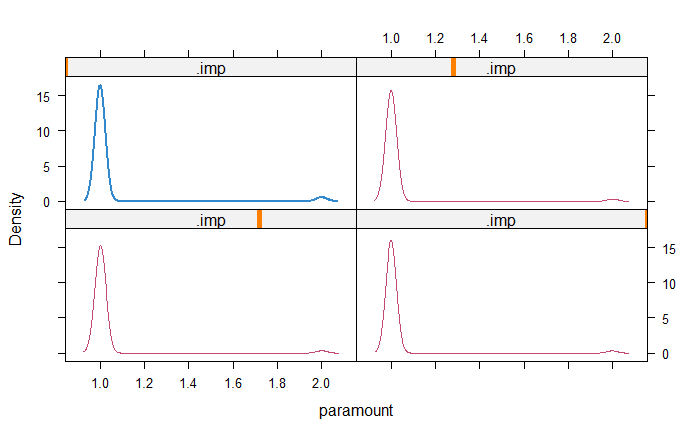

`r`r stripplot(imputations_cart, paramount, col = c(, mdc(2)), pch = c(1, 20))

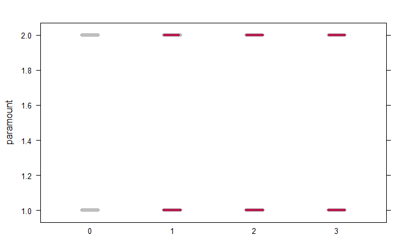

`r`r densityplot(imputations_cart, ~ mgm | .imp)

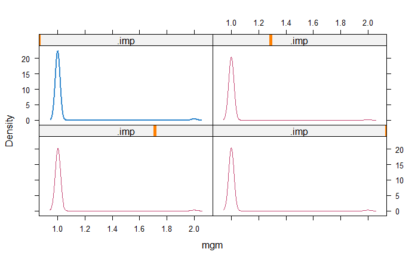